# Latihan 3 MPDW

## Library

```r
library(forecast)
library(TTR)
library(TSA)
library(lmtest)
library(dplyr)
library(dLagM)
```

## White Noise

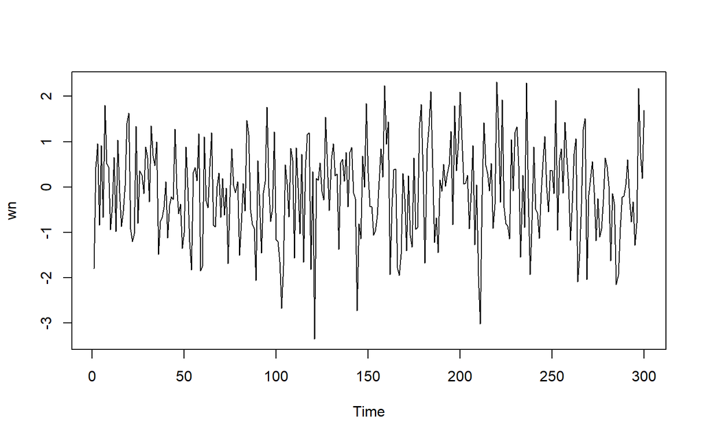

```r
set.seed(1017)
n <- 300
wn <- rnorm(n)
ts.plot(wn)
```

## MA(2)

### Manual

$$y_t = e_t-0.4e_{t-1}-0.6e_{t-2}$$

```r
set.seed(1017)
ma2 <- c(1:n)

for(i in 3:n){
  ma2[i] <- wn[i] + 0.4 * wn[i - 1] + 0.6 * wn[i - 2]
}
ma2
```

```
##   [1]  1.000000000  2.000000000  0.051907638 -0.190457994  1.152192106
##   [6] -0.812776398  2.083395853  0.828742695  1.723384316 -0.458120868
##  [11] -0.555371259 -0.087390024 -0.991359214  1.031730557 -0.316578294
##  [16] -0.308583571 -0.971560252 -0.717203949  1.093917295  2.212611623
##  [21]  0.561693955 -0.595880864 -2.080851708  0.204113888 -0.891014299
##  [26]  0.845071167 -0.077408623  0.174789391  0.984222553  0.921166222
##  [31]  0.462425674  1.608564724  1.032679787  1.558288519  1.602656055
##  [36] -0.806284982 -0.758290286 -1.869988493 -1.177799176 -0.471391252
##  [41] -1.350769961 -0.790362949 -1.057901931 -0.613596539  1.032154262
##  [46]  0.304013881  0.165402475 -0.639103765 -1.857482512 -1.783282922
##  [51] -0.328789796 -0.253514641 -0.678762977 -2.318243872 -1.143041193
##  [56] -0.538774236  0.501959588  1.488393678 -1.295957806 -1.789153929
##  [61] -0.706224593 -0.921180809  0.080043601  0.083685871  1.105643028
##  [66] -0.091544923 -0.496743389 -0.840326224 -0.216790440 -0.541949144
##  [71]  0.095616282 -0.951882412 -0.161192318 -2.068099700 -0.919193934
```

[output cut: 45 more lines]

### arima.sim

```r
ma2_sim <- arima.sim(list(order=c(0,0,2), ma=c(0.4,0.6)), n=300)
ma2_sim
```

```
## Time Series:
## Start = 1
## End = 300
## Frequency = 1
##   [1]  0.051907638 -0.190457994  1.152192106 -0.812776398  2.083395853
##   [6]  0.828742695  1.723384316 -0.458120868 -0.555371259 -0.087390024
##  [11] -0.991359214  1.031730557 -0.316578294 -0.308583571 -0.971560252
##  [16] -0.717203949  1.093917295  2.212611623  0.561693955 -0.595880864
##  [21] -2.080851708  0.204113888 -0.891014299  0.845071167 -0.077408623
##  [26]  0.174789391  0.984222553  0.921166222  0.462425674  1.608564724
##  [31]  1.032679787  1.558288519  1.602656055 -0.806284982 -0.758290286
##  [36] -1.869988493 -1.177799176 -0.471391252 -1.350769961 -0.790362949
##  [41] -1.057901931 -0.613596539  1.032154262  0.304013881  0.165402475
##  [46] -0.639103765 -1.857482512 -1.783282922 -0.328789796 -0.253514641
##  [51] -0.678762977 -2.318243872 -1.143041193 -0.538774236  0.501959588
```

[output cut: 49 more lines]

## Karakteristik MA(2)

### Plot Time Series

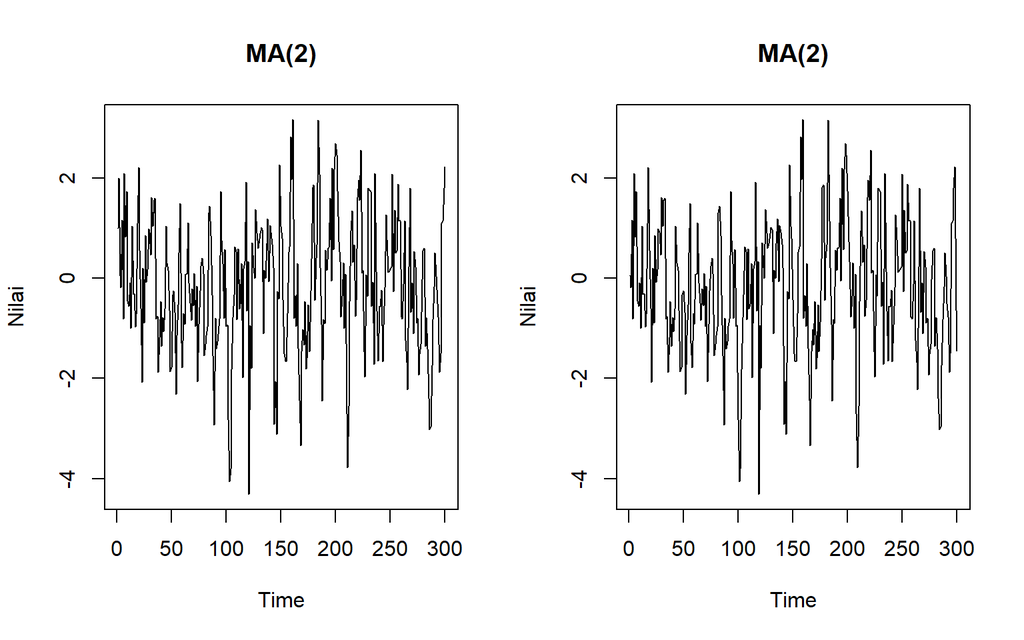

```r
par(mfrow = c(1, 2))
ts.plot(ma2, main = "MA(2)", ylab = "Nilai")
ts.plot(ma2_sim, main = "MA(2)", ylab = "Nilai")
```

Berdasarkan plot time series, terlihat bahwa MA(2) yang dibangkitkan stasioner dalam rataan.

### Plot ACF

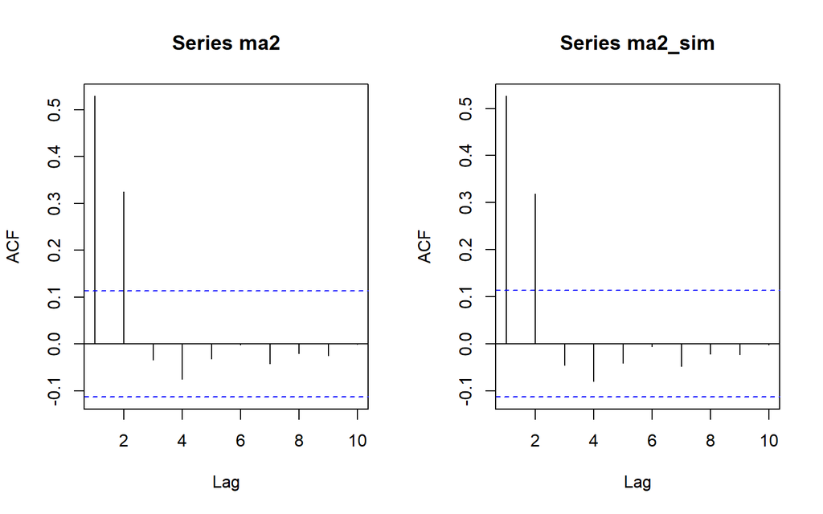

```r
par(mfrow = c(1, 2))
acf(ma2,lag.max = 10)
acf(ma2_sim,lag.max = 10)
```

Berdasarkan plot ACF tersebut, terlihat bahwa plot ACF dari MA(2) cuts off di lag kedua.

### Plot PACF

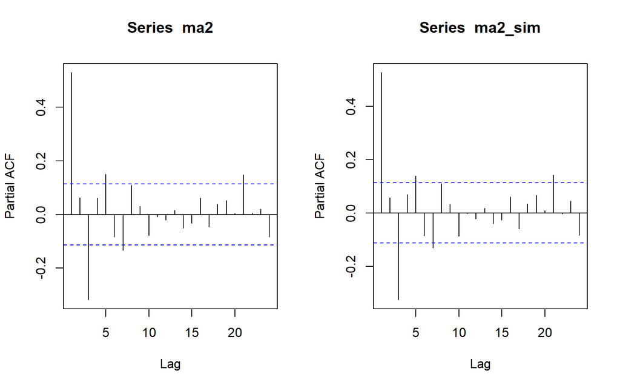

```r
par(mfrow = c(1, 2))
pacf(ma2)
pacf(ma2_sim)
```

Berdasarkan plot PACF tersebut, terlihat bahwa plot PACF dari MA(2) cenderung tails off.

### Plot EACF

```r
TSA::eacf(ma2)
```

```
## AR/MA
##   0 1 2 3 4 5 6 7 8 9 10 11 12 13
## 0 x x o o o o o o o o o  o  o  o
## 1 x x x o o o o o o o o  o  o  o
## 2 x x x o o o o o o o o  o  o  o
## 3 x x x o x o o o o o o  o  o  o
## 4 x x o x x o o o o o o  o  o  o
## 5 x x o x x o o o o o o  o  o  o
## 6 x x o x x o x o o o o  o  o  o
## 7 x x o x o o x x x o o  o  o  o
```

```r
TSA::eacf(ma2_sim)
```

```
## AR/MA
##   0 1 2 3 4 5 6 7 8 9 10 11 12 13
## 0 x x o o o o o o o o o  o  o  o
## 1 o x x o o o o o o o o  o  o  o
## 2 x x x o o o o o o o o  o  o  o
## 3 x x x o x o o o o o o  o  o  o
## 4 x x o x x o o o o o o  o  o  o
## 5 x x o x o x o o o o o  o  o  o
## 6 x x o x o o o o o o o  o  o  o
## 7 x x o x o o x x x o o  o  o  o
```

Berdasarkan pola segitiga nol pada plot EACF, terlihat bahwa segitiga nol berada pada ordo AR(0) dan ordo MA(2)

## Scatterplot Antar Lag

### Korelasi antara $Y_{t}$ dengan $Y_{t-1}$

```r
yt_ma <- ma2[-1]
yt_1_ma <- ma2[-300]

yt_ma_sim <- ma2_sim[-1]
yt_1_ma_sim <- ma2_sim[-300]
```

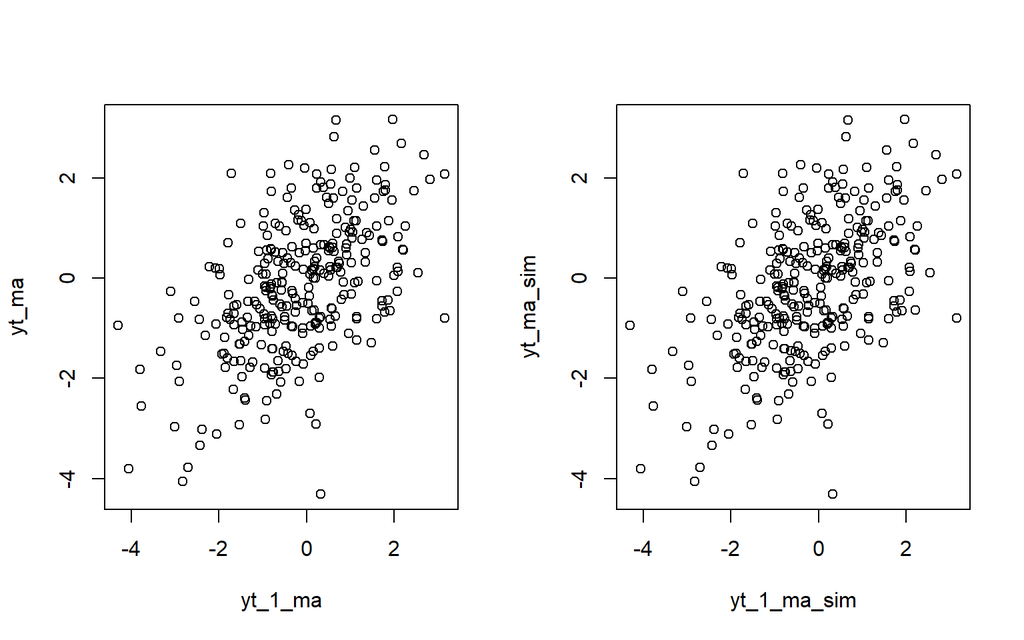

```r
par(mfrow = c(1, 2))
plot(y = yt_ma, x = yt_1_ma)
plot(y = yt_ma_sim, x = yt_1_ma_sim)
```

Berdasarkan scatterplot tersebut, terlihat bahwa terdapat hubungan positif antara $Y_t$ dengan $Y_{t−1}$. Hal ini sesuai dengan teori yang ada.

```r
cor(yt_ma, yt_1_ma)
```

```
## [1] 0.5324983
```

```r
cor(yt_ma_sim, yt_1_ma_sim)
```

```
## [1] 0.527313
```

Korelasi antara $Y_t$ dengan $Y_{t−1}$ memiliki nilai $0.5324983$ (manual) atau $0.527313$ (arima.sim) yang artinya ada hubungan linear yang cukup kuat antara $Y_t$ dengan $Y_{t−1}$.

### Autokorelasi Teoritis

$$\rho_1 =
\frac{-\theta_{1}+\theta_{1}\theta_{2}}{1+(\theta_{1})^2+(\theta_{2})^2}
= \frac{-(-0.4)+(-0.4)(-0.6)}{1+(-0.4)^2+(-0.6)^2}
\approx 0.421$$

### Korelasi antara $Y_{t}$ dengan $Y_{t-2}$

```r
yt_ma2 <- ma2[-c(1,2)]
yt_2_ma <- ma2[-c(299,300)]

yt_ma2_sim <- ma2_sim[-c(1,2)]
yt_2_ma_sim <- ma2_sim[-c(299,300)]
```

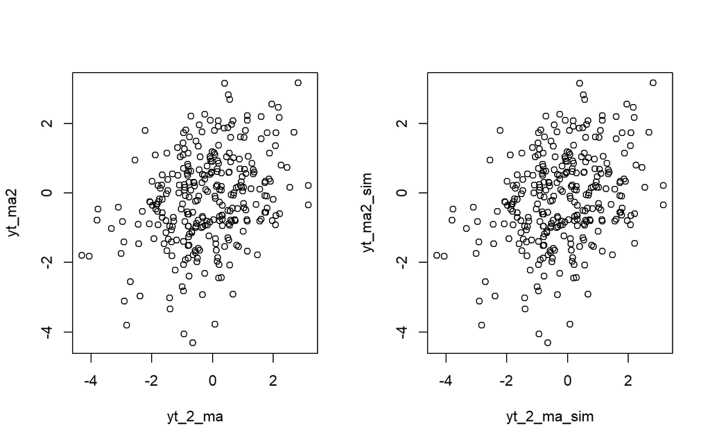

```r
par(mfrow = c(1,2))
plot(y = yt_ma2, x = yt_2_ma)
plot(y = yt_ma2_sim, x = yt_2_ma_sim)
```

Berdasarkan scatterplot tersebut, terlihat bahwa terdapat hubungan positif antara $Y_t$ dengan $Y_{t−2}$. Hal ini masih sesuai dengan teori yang ada.

```r
cor(yt_ma2, yt_2_ma)
```

```
## [1] 0.329209
```

```r
cor(yt_ma2_sim, yt_2_ma_sim)
```

```
## [1] 0.3195598
```

### Autokorelasi Teoritis

$$\rho_2 = \frac{-\theta_{2}}{1+(\theta_{1})^2+(\theta_{2})^2}
= \frac{-(-0.6)}{1+(-0.4)^2+(-0.6)^2}
= 0.395$$

### Korelasi antara $Y_{t}$ dengan $Y_{t-3}$

```r
yt_ma3 <- ma2[-c(1,2,3)]
yt_3_ma <- ma2[-c(298,299,300)]

yt_ma3_sim <- ma2_sim[-c(1,2,3)]
yt_3_ma_sim <- ma2_sim[-c(298,299,300)]
```

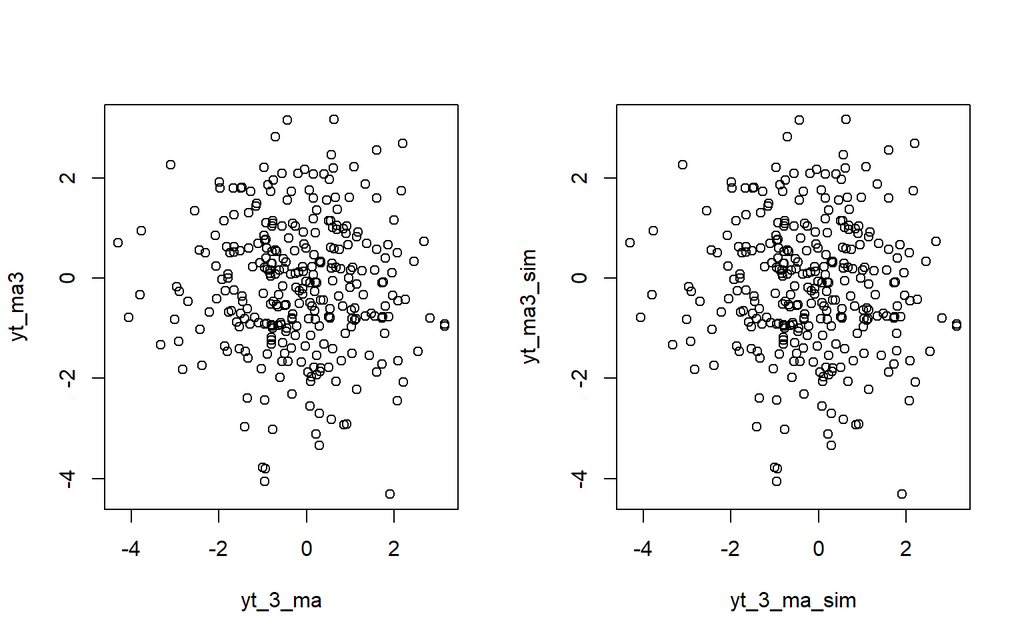

```r
par(mfrow = c(1,2))
plot(y = yt_ma3, x = yt_3_ma)
plot(y = yt_ma3_sim, x = yt_3_ma_sim)
```

Berdasarkan scatterplot tersebut, terlihat bahwa cenderung tidak terdapat hubungan antara $Y_t$ dengan $Y_{t−3}$

```r
cor(yt_ma3, yt_3_ma)
```

```
## [1] -0.03444889
```

```r
cor(yt_ma3_sim, yt_3_ma_sim)
```

```
## [1] -0.04598599
```

### Autokorelasi Teoritis

Korelasi antara $Y_t$ dengan $Y_{t−3}$ mendekati angka 0 yang artinya hampir tidak ada hubungan linear antara $Y_t$ dengan $Y_{t−3}$.

## AR(2)

### Manual

```r
set.seed(1017)
n <- length(wn)

ar2 <- numeric(n)

for (i in 3:n){
  ar2[i] <- wn[i] + 0.5 * ar2[i - 1] + 0.2 * ar2[i - 2]
}
ar2
```

```
##   [1]  0.000000000  0.000000000  0.956793378 -0.360402428  0.924793187
##   [6] -0.284635110  1.847835987  1.378626435  1.494493603  0.083624667
##  [11] -0.100289150  0.619198869 -0.698264891  0.809989377  0.127334494
##  [16] -0.648884791 -0.837911453 -0.525632302  0.977640274  2.019229584
##  [21]  0.267799209 -0.664519432 -1.316239418  0.549465082 -0.793201386
##  [26]  0.075944701  0.139674125 -0.061912853  0.883771263  1.084115451
##  [31]  0.387316978  1.758876870  1.649120502  1.648699500  2.152553153
##  [36] -0.083038552 -0.372704501 -0.874837094 -0.963990257 -0.544415196
##  [41] -1.589576066 -1.311734266 -1.193716750 -1.139990089  0.467690454
##  [46] -0.032239533 -0.507801813 -0.642512478 -1.776301565 -2.029244016
##  [51] -0.481544844 -0.647916414 -1.631514563 -2.778308369 -1.398562735
##  [56] -0.820694340 -0.551936226  0.732488080 -1.592013130 -2.403071945
##  [61] -0.416016038 -0.999234444 -1.040885550 -0.267010523  0.857488072
##  [66] -0.467838654 -0.941395133 -0.547093802 -0.158100913 -0.862211264
##  [71] -0.279847723 -0.933154535 -0.545150617 -2.145791341 -1.412923395
```

[output cut: 45 more lines]

### arima.sim

```r
ar2_sim <- arima.sim(list(order=c(2,0,0), ar=c(0.5,0.2)), n=300)
ar2_sim
```

```
## Time Series:
## Start = 1
## End = 300
## Frequency = 1
##   [1]  0.074915132  0.138889236 -0.062511212  0.883315106  1.083767700
##   [6]  0.387051871  1.758674766  1.648966429  1.648582043  2.152463610
##  [11] -0.083106815 -0.372756541 -0.874876767 -0.964020501 -0.544438252
##  [16] -1.589593643 -1.311747666 -1.193726965 -1.139997877  0.467684517
##  [21] -0.032244059 -0.507805264 -0.642515109 -1.776303570 -2.029245545
##  [26] -0.481546010 -0.647917302 -1.631515241 -2.778308885 -1.398563129
##  [31] -0.820694640 -0.551936455  0.732487905 -1.592013263 -2.403072046
##  [36] -0.416016115 -0.999234503 -1.040885595 -0.267010558  0.857488046
##  [41] -0.467838674 -0.941395149 -0.547093814 -0.158100922 -0.862211271
##  [46] -0.279847728 -0.933154538 -0.545150620 -2.145791343 -1.412923396
##  [51] -0.286906875 -0.387240016 -0.371845501 -0.145281057 -1.658912497
```

[output cut: 49 more lines]

## Karakteristik AR(2)

### Plot Time Series

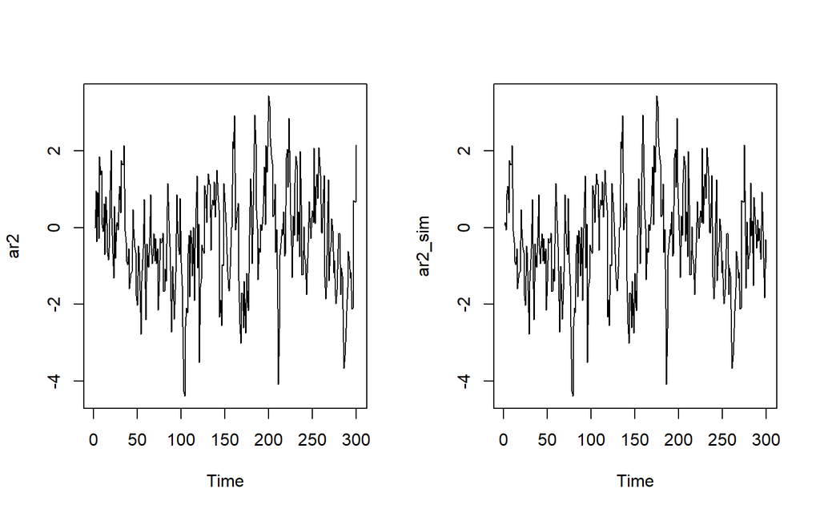

```r
par(mfrow = c(1,2))
ts.plot(ar2)
ts.plot(ar2_sim)
```

Berdasarkan plot time series, terlihat bahwa AR(2) yang dibangkitkan stasioner dalam rataan.

### Plot ACF

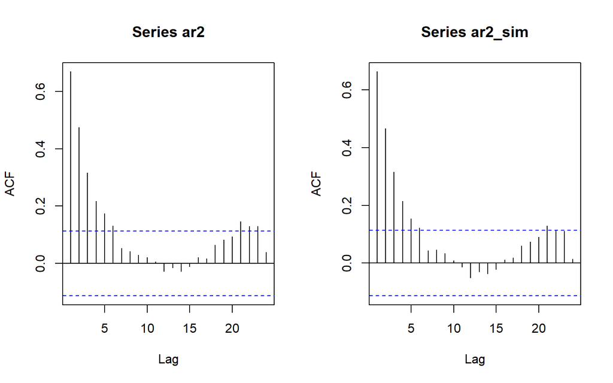

```r
par(mfrow = c(1,2))
acf(ar2)
acf(ar2_sim)
```

Berdasarkan plot ACF tersebut terlihat bahwa plot ACF dari AR(2) cenderung tails off dan cenderung membentuk pola grafik sinus.

### Plot PACF

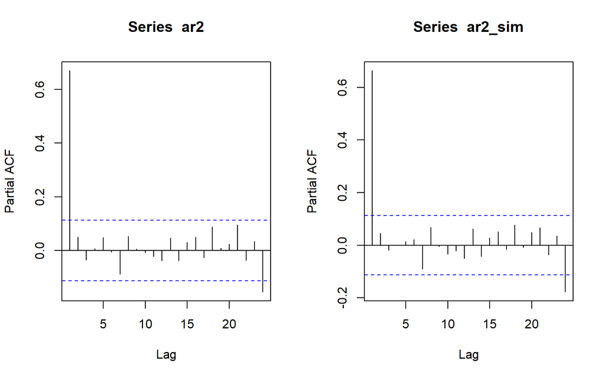

```r
par(mfrow = c(1,2))
pacf(ar2)
pacf(ar2_sim)
```

Berdasarkan plot PACF tersebut, terlihat bahwa plot PACF dari AR(2) cuts off di lag pertama. Hal ini bisa terjadi karena $\phi_{2}$ cukup kecil dibanding $\phi_{1}$ sehingga estimasi PACF pada lag 2 bisa sangat kecil.

### Plot EACF

```r
TSA::eacf(ar2)
```

```
## AR/MA
##   0 1 2 3 4 5 6 7 8 9 10 11 12 13
## 0 x x x x x x o o o o o  o  o  o
## 1 o o o o o o o o o o o  o  o  o
## 2 x o o o o o o o o o o  o  o  o
## 3 x x o o o o o o o o o  o  o  o
## 4 x x o o o o o o o o o  o  o  o
## 5 x x x o o o o o o o o  o  o  o
## 6 x x o o x o o o o o o  o  o  o
## 7 x x x x x x o o o o o  o  o  o
```

```r
TSA::eacf(ar2_sim)
```

```
## AR/MA
##   0 1 2 3 4 5 6 7 8 9 10 11 12 13
## 0 x x x x x x o o o o o  o  o  o
## 1 o o o o o o x o o o o  o  o  o
## 2 x o o o o o o o o o o  o  o  o
## 3 o o o o o o o o o o o  o  o  o
## 4 o x o o o o o o o o o  o  o  o
## 5 x o x o o o o o o o o  o  o  o
## 6 x x x o x o o o o o o  o  o  o
## 7 x x o x x o o o o o o  o  o  o
```

Berdasarkan pola segitiga nol pada plot EACF, terlihat bahwa plot tersebut bukan membentuk AR(2) melainkan AR(1). Hal ini bisa terjadi karena sinyal lag 2 bisa lemah sehingga estimasi PACF lag 2 tidak signifikan yang mengakibatkan EACF menganggap p = 1.

## Scatterplot Antar Lag

### Korelasi antara $Y_{t}$ dengan $Y_{t-1}$

```r
yt_ar <- ar2[-1]
yt_1_ar <- ar2[-300]

yt_ar_sim <- ar2_sim[-1]
yt_1_ar_sim <- ar2_sim[-300]
```

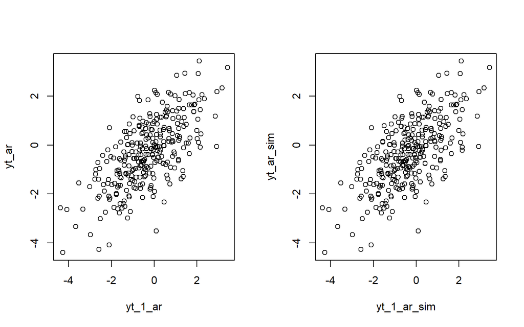

```r
par(mfrow = c(1,2))
plot(y = yt_ar, x = yt_1_ar)
plot(y = yt_ar_sim, x = yt_1_ar_sim)
```

Berdasarkan scatterplot tersebut, terlihat bahwa terdapat hubungan positif antara $Y_t$ dengan $Y_{t−1}$. Hal ini sesuai dengan teori yang ada.

```r
cor(yt_ar, yt_1_ar)
```

```
## [1] 0.6734004
```

```r
cor(yt_ar_sim, yt_1_ar_sim)
```

```
## [1] 0.6638093
```

Korelasi antara $Y_t$ dengan $Y_{t−1}$ memiliki nilai $0.6734004$ (manual) atau $0.6638093$ (arimma.sim) yang artinya ada hubungan linear yang cukup kuat antara $Y_t$ dengan $Y_{t−1}$.

### Autokorelasi Teoritis

$$\rho_{1} = \frac{\phi_{1}}{1 - \phi_{2}}
= \frac{0.5}{1 - 0.2}
= 0.625$$

### Korelasi antara $Y_{t}$ dengan $Y_{t-2}$

```r
yt_ar2 <- ar2[-c(1,2)]
yt_2_ar <- ar2[-c(299,300)]

yt_ar2_sim <- ar2_sim[-c(1,2)]
yt_2_ar_sim <- ar2_sim[-c(299,300)]
```

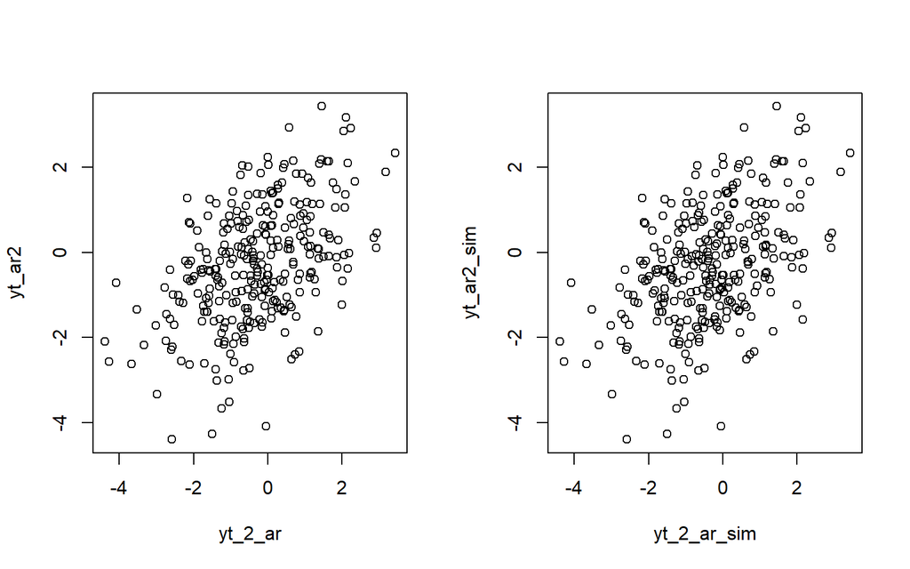

```r
par(mfrow = c(1,2))
plot(y = yt_ar2, x = yt_2_ar)
plot(y = yt_ar2_sim, x = yt_2_ar_sim)
```

Berdasarkan scatterplot tersebut, terlihat bahwa terdapat hubungan positif antara $Y_t$ dengan $Y_{t−2}$. Hal ini masih sesuai dengan teori yang ada.

```r
cor(yt_ar2, yt_2_ar)
```

```
## [1] 0.4788909
```

```r
cor(yt_ar2_sim, yt_2_ar_sim)
```

```
## [1] 0.4667212
```

Korelasi antara $Y_t$ dengan $Y_{t−2}$ memiliki nilai $0.4788909$ (manual) atau $0.4667212$ (arima.sim) yang artinya ada hubungan linear yang cukup kuat antara $Y_t$ dengan $Y_{t−2}$.

### Autokorelasi Teoritis

$$\rho_{2} = \frac{\phi_{2}(1-\phi_{2})+(\phi_{1})^2}{1 - \phi_{2}}
= \frac{0.2(1-0.2)+(0.5)^2}{1 - 0.2}
= 0.5125$$

### Korelasi antara $Y_{t}$ dengan $Y_{t-3}$

```r
yt_ar3 <- ar2[-c(1,2,3)]
yt_3_ar <- ar2[-c(298,299,300)]

yt_ar3_sim <- ar2_sim[-c(1,2,3)]
yt_3_ar_sim <- ar2_sim[-c(298,299,300)]
```

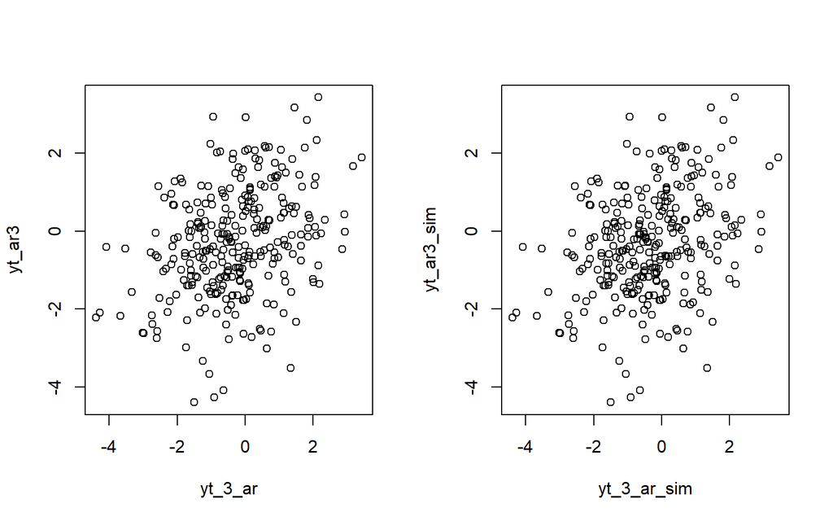

```r
par(mfrow = c(1,2))
plot(y = yt_ar3, x = yt_3_ar)
plot(y = yt_ar3_sim, x = yt_3_ar_sim)
```

Berdasarkan scatterplot tersebut, terlihat bahwa terdapat hubungan positif antara $Y_t$ dengan $Y_{t−3}$. Hal ini masih sesuai dengan teori yang ada.

```r
cor(yt_ar3, yt_3_ar)
```

```
## [1] 0.3196784
```

```r
cor(yt_ar3_sim, yt_3_ar_sim)
```

```
## [1] 0.3163653
```

Korelasi antara $Y_t$ dengan $Y_{t−3}$ memiliki nilai $0.3196784$ (manual) atau $0.3163653$ (arima.simm) yang artinya ada hubungan linear yang lemah antara $Y_t$ dengan $Y_{t−3}$.

### Autokorelasi Teoritis

$$\rho_{3} = {\phi_{1}\rho_{2}+\phi_{2}\rho_{1}}
= (0.5)(0.5125)+(0.2)(0.625)
= 0.38125$$

## ARMA(2,2)

### Manual

```r
set.seed(1017)
n = length(wn)

y.arma = c(1:n)
for (i in 3:n) {
  y.arma[i] <- 0.5 * y.arma[i - 1] + 0.2 * y.arma[i - 2] + wn[i] + 0.4 * wn[i - 1] + 0.6 * wn[i - 2]
}
y.arma
```

```
##   [1]  1.00000000  2.00000000  1.25190764  0.83549583  1.82032155  0.26448354
##   [7]  2.57970193  2.17149037  3.32506989  1.63871215  0.92899879  0.70485180
##  [13] -0.45313355  0.94613414  0.06586207 -0.08642571 -1.00160069 -1.23528944
##  [19]  0.27595244  2.10352995  1.66864942  0.65914984 -1.41754691 -0.37282960
##  [25] -1.36093848  0.09003601 -0.30457831  0.04050744  0.94356061  1.40104801
##  [31]  1.35166180  2.56460523  2.58531476  3.36386695  3.80165248  1.76731465
##  [37]  0.88569753 -1.07367680 -1.53749807 -1.45487565 -2.38570740 -2.27419178
##  [43] -2.67213930 -2.40450454 -0.70452587 -0.52914996 -0.24007768 -0.86497260
##  [49] -2.33798435 -3.12526962 -2.35902147 -2.05807930 -2.17960692 -3.81966319
##  [55] -3.48879417 -3.04710396 -1.71935123  0.01929727 -1.63017942 -2.60038418
##  [61] -2.33245257 -2.60748393 -1.69018888 -1.28290535  0.12615258 -0.28504971
##  [67] -0.61403773 -1.20435503 -0.94177550 -1.25370790 -0.71959277 -1.56242038
##  [73] -1.08632106 -2.92374430 -2.59833030 -2.13955103 -1.34975680 -0.69888563
##  [79] -0.52636326 -1.94013222 -2.39664809 -2.73582356 -2.81573446 -0.64910785
##  [85]  0.54227848  0.99240521  0.27499507 -1.20298595 -3.47159886 -2.77096007
```

[output cut: 35 more lines]

### arima.sim

```r
arma_sim <- arima.sim(list(order = c(2,0,2), ar = c(0.5,0.2), ma = c(0.4,0.6)), n = 300)
arma_sim
```

```
## Time Series:
## Start = 1
## End = 300
## Frequency = 1
##   [1]  0.03905500  0.94245335  1.40020390  1.35101829  2.56411465  2.58494077
##   [7]  3.36358183  3.80143513  1.76714895  0.88557121 -1.07377310 -1.53757148
##  [13] -1.45493161 -2.38575006 -2.27422430 -2.67216410 -2.40452345 -0.70454028
##  [19] -0.52916095 -0.24008606 -0.86497898 -2.33798921 -3.12527333 -2.35902430
##  [25] -2.05808146 -2.17960857 -3.81966445 -3.48879513 -3.04710469 -1.71935178
##  [31]  0.01929685 -1.63017974 -2.60038443 -2.33245275 -2.60748407 -1.69018899
##  [37] -1.28290544  0.12615251 -0.28504975 -0.61403776 -1.20435506 -0.94177552
##  [43] -1.25370792 -0.71959278 -1.56242039 -1.08632107 -2.92374431 -2.59833030
##  [49] -2.13955104 -1.34975680 -0.69888563 -0.52636327 -1.94013222 -2.39664809
##  [55] -2.73582357 -2.81573446 -0.64910785  0.54227848  0.99240521  0.27499507
##  [61] -1.20298595 -3.47159886 -2.77096007 -3.49091854 -3.56785496 -3.43885497
```

[output cut: 39 more lines]

## Karakteristik ARMA(2,2)

### Plot Time Series

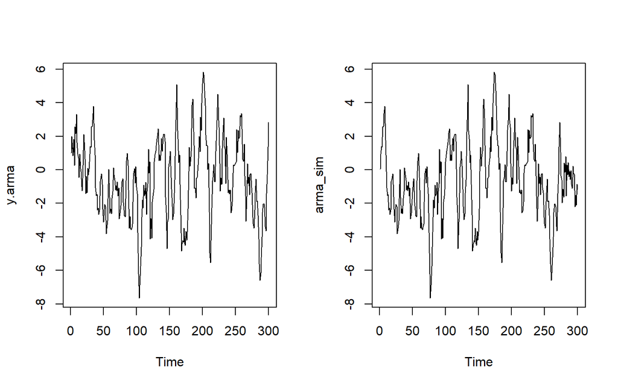

```r
par(mfrow = c(1, 2))
ts.plot(y.arma)
ts.plot(arma_sim)
```

Berdasarkan plot time series, terlihat bahwa ARMA(2,2) yang dibangkitkan stasioner dalam rataan.

### Plot ACF

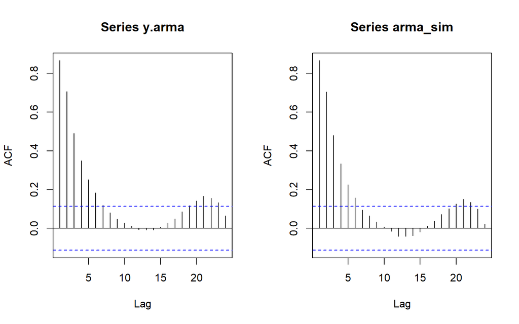

```r
par(mfrow = c(1, 2))
acf(y.arma)
acf(arma_sim)
```

Berdasarkan plot ACF tersebut terlihat bahwa plot ACF dari ARMA(2,2) cenderung tails off.

### Plot PACF

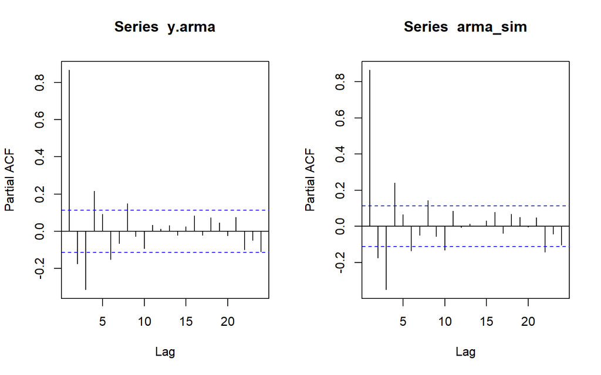

```r
par(mfrow = c(1, 2))
pacf(y.arma)
pacf(arma_sim)
```

Berdasarkan plot PACF tersebut, terlihat bahwa plot PACF dari ARMA(2,2) cenderung tails off.

### Plot EACF

```r
TSA::eacf(y.arma)
```

```
## AR/MA
##   0 1 2 3 4 5 6 7 8 9 10 11 12 13
## 0 x x x x x x x o o o o  o  o  o
## 1 x x o o o o o o o o o  o  o  o
## 2 x x o o o o o o o o o  o  o  o
## 3 x x o o o o o o o o o  o  o  o
## 4 x x o o x o o o o o o  o  o  o
## 5 x x o x o o o o o o o  o  o  o
## 6 x x x x x o x o o o o  o  o  o
## 7 x x o x x o x x o o o  o  o  o
```

```r
TSA::eacf(arma_sim)
```

```
## AR/MA
##   0 1 2 3 4 5 6 7 8 9 10 11 12 13
## 0 x x x x x x o o o o o  o  o  o
## 1 x x o o o o o o o o o  o  o  o
## 2 x x x o o o o o o o o  o  o  o
## 3 x x x o o o o o o o o  o  o  o
## 4 x x o o x o o o o o o  o  o  o
## 5 x x x x x o o o o o o  o  o  o
## 6 x x x o o o o o o o o  o  o  o
## 7 x x x x o o x x o o o  o  o  o
```

Berdasarkan pola segitiga nol pada plot EACF, terlihat bahwa plot tersebut membentuk ARMA(1,2). Hal ini karena EACF adalah metode heuristik dan dengan sampel n=300 dan konfigurasi parameter tertentu, pola sampel ACF/PACF bisa mirip ARMA(1,2). Jadi EACF bisa memberikan kandidat lain.

## Scatterplot Antar Lag

### Korelasi antara $Y_{t}$ dengan $Y_{t-1}$

```r
yt_arma <- y.arma[-1]
yt_1_arma <- y.arma[-300]

yt_arma_sim <- arma_sim[-1]
yt_1_arma_sim <- arma_sim[-300]
```

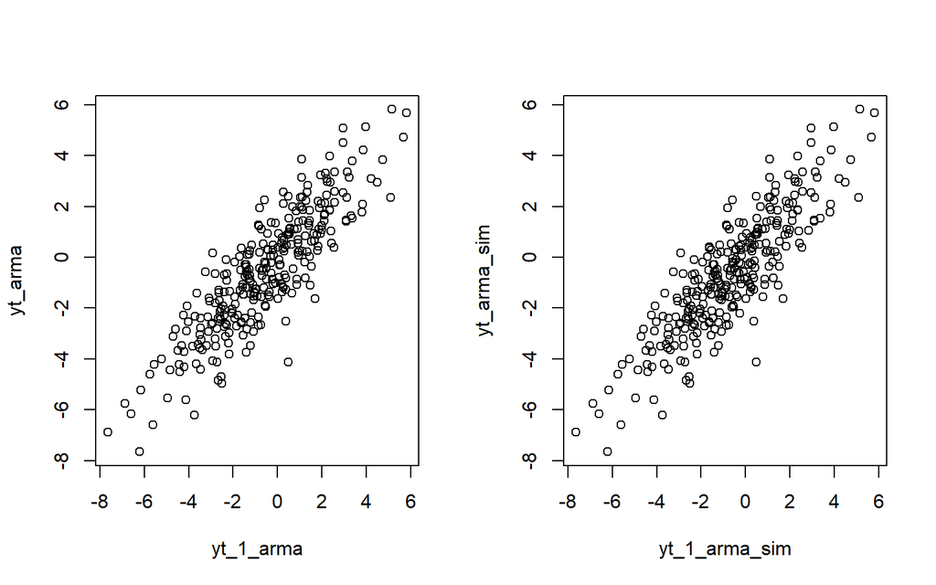

```r
par(mfrow = c(1,2))
plot(y = yt_arma, x = yt_1_arma)
plot(y = yt_arma_sim, x = yt_1_arma_sim)
```

Berdasarkan scatterplot tersebut, terlihat bahwa terdapat hubungan positif antara $Y_t$ dengan $Y_{t−1}$. Hal ini sesuai dengan teori yang ada.

```r
cor(yt_arma, yt_1_arma)
```

```
## [1] 0.8692143
```

```r
cor(yt_arma_sim, yt_1_arma_sim)
```

```
## [1] 0.865305
```

Korelasi antara $Y_t$ dengan $Y_{t−1}$ memiliki nilai $0.8692143$ (manual) atau $0.865305$ (arima.sim) yang artinya ada hubungan linear yang sangat kuat antara $Y_t$ dengan $Y_{t−1}$.

### Autokorelasi Teoritis

$$\rho_1 = \frac{(1 - \phi_2)\theta_1 + (\phi_1 - \phi_2)\theta_2 +
\phi_1(1 + \theta_1^2 + \theta_2^2)}
{(1 - \phi_2)(1 + \theta_1^2 + \theta_2^2) + 2(\phi_1 -
\phi_2)\theta_1\theta_2}
= \frac{(1 - 0.2)(0.4) + (0.5 - 0.2)(0.6) + 0.5(1 + 0.4^2 + 0.6^2)}
{(1 - 0.2)(1 + 0.4^2 + 0.6^2) + 2(0.5 - 0.2)(0.4)(0.6)}
= \frac{1.26}{1.36} \approx 0.926$$

### Korelasi antara $Y_{t}$ dengan $Y_{t-2}$

```r
yt_arma2 <- y.arma[-c(1,2)]
yt_2_arma <- y.arma[-c(299,300)]

yt_arma2_sim <- arma_sim[-c(1,2)]
yt_2_arma_sim <- arma_sim[-c(299,300)]
```

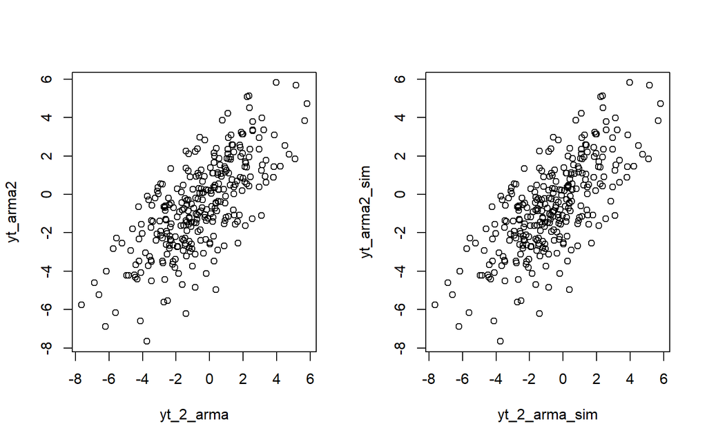

```r
par(mfrow = c(1,2))
plot(y = yt_arma2, x = yt_2_arma)
plot(y = yt_arma2_sim, x = yt_2_arma_sim)
```

Berdasarkan scatterplot tersebut, terlihat bahwa terdapat hubungan positif antara $Y_t$ dengan $Y_{t−2}$. Hal ini masih sesuai dengan teori yang ada.

```r
cor(yt_arma2, yt_2_arma)
```

```
## [1] 0.7104349
```

```r
cor(yt_arma2_sim, yt_2_arma_sim)
```

```
## [1] 0.7051511
```

Korelasi antara $Y_t$ dengan $Y_{t−2}$ memiliki nilai $0.7104349$ (manual) atau $0.7051511$ (arima.sim) yang artinya ada hubungan linear yang sangat kuat antara $Y_t$ dengan $Y_{t−2}$.

### Autokorelasi Teoritis

$$\rho_2 = \frac{(\phi_1 + \theta_1\theta_2)(1 - \phi_2) + (\phi_1^2 -
\phi_2)(1 + \theta_1^2 + \theta_2^2) + \theta_2(\theta_1 +
\phi_1\theta_2)}
{(1 - \phi_2)(1 + \theta_1^2 + \theta_2^2) + 2(\phi_1 -
\phi_2)\theta_1\theta_2}
= \frac{(0.5 + 0.4 \times 0.6)(0.8) + (0.5^2 - 0.2)(1 + 0.4^2 + 0.6^2) +
0.6(0.4 + 0.5 \times 0.6)}
{(1-0.2)(1 + 0.4^2 + 0.6^2) + 2(0.5 - 0.2)(0.4)(0.6)}
= \frac{1.088}{1.36} = 0.8$$

### Korelasi antara $Y_{t}$ dengan $Y_{t-3}$

```r
yt_arma3 <- y.arma[-c(1,2,3)]
yt_3_arma <- y.arma[-c(298,299,300)]

yt_arma3_sim <- arma_sim[-c(1,2,3)]
yt_3_arma_sim <- arma_sim[-c(298,299,300)]
```

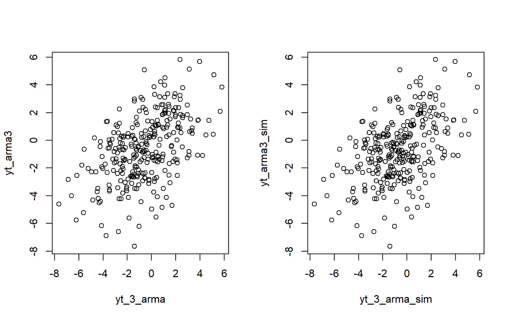

```r
par(mfrow = c(1,2))
plot(y = yt_arma3, x = yt_3_arma)
plot(y = yt_arma3_sim, x = yt_3_arma_sim)
```

Berdasarkan scatterplot tersebut, terlihat bahwa terdapat hubungan positif antara $Y_t$ dengan $Y_{t−3}$. Hal ini sesuai dengan teori yang ada.

```r
cor(yt_arma3, yt_3_arma)
```

```
## [1] 0.4936458
```

```r
cor(yt_arma3_sim, yt_3_arma_sim)
```

```
## [1] 0.480585
```

Korelasi antara $Y_t$ dengan $Y_{t−3}$ memiliki nilai $0.4936458$ (manual) atau $0.480585$ (arima.sim) yang artinya ada hubungan linear yang cukup kuat antara $Y_t$ dengan $Y_{t−3}$.

### Autokorelasi Teoritis

$$\rho_3 = \phi_1 \rho_2 + \phi_2 \rho_1
= (0.5)(0.8) + (0.2)(0.926)
= 0.5852$$